# Data Wrangling

#### clean the names

```python
# assess the names
names = master_clean.name.unique()
names
```

```
array(['Tilly', 'Archie', 'Darla', 'Franklin', 'None', 'Jax', 'Zoey',
       'Cassie', 'Koda', 'Bruno', 'Ted', 'Stuart', 'Oliver', 'Jim',
       'Zeke', 'Ralphus', 'Gerald', 'Jeffrey', 'Canela', 'Maya', 'Mingus',
       'Roscoe', 'Waffles', 'Jimbo', 'Maisey', 'Earl', 'Lola', 'Kevin',
       'Yogi', 'Noah', 'Bella', 'Grizzwald', 'Rusty', 'Gus', 'Stanley',
       'Alfy', 'Koko', 'Rey', 'Gary', 'a', 'Jesse', 'Romeo', 'Bailey',
       'Duddles', 'Jack', 'Beau', 'Snoopy', 'Shadow', 'Emmy', 'Aja',
       'Penny', 'Dante', 'Nelly', 'Ginger', 'Benedict', 'Venti', 'Goose',
       'Nugget', 'Cash', 'Jed', 'Sebastian', 'Sierra', 'Monkey', 'Harry',
       'Kody', 'Lassie', 'Rover', 'Napolean', 'Boomer', 'Cody', 'Rumble',
       'Dewey', 'Scout', 'Gizmo', 'Walter', 'Cooper', 'Harold', 'Shikha',
       'Lili', 'Jamesy', 'Coco', 'Sammy', 'Meatball', 'Paisley',
       'Neptune', 'Belle', 'Quinn', 'Zooey', 'Dave', 'Hobbes', 'Burt',
       'Lorenzo', 'Carl', 'Milky', 'Trooper', 'quite', 'Sophie', 'Wyatt',
       'Rosie', 'Thor', 'Oscar', 'Callie', 'Cermet', 'Marlee', 'Arya',
       'Einstein', 'Alice', 'Benny', 'Aspen', 'Jarod', 'Sailor', 'Snoop',
       'Kyle', 'Leo', 'Riley', 'Noosh', 'Odin', 'Jerry', 'Rontu',
       'Cannon', 'Furzey', 'Daisy', 'Tuck', 'Barney', 'Vixen', 'Jarvis',
       'Mimosa', 'Pickles', 'Brady', 'Luna', 'Margo', 'Sadie', 'Hank',
       'Tycho', 'Charlie', 'Indie', 'Winnie', 'George', 'Bentley', 'Max',
       'Dawn', 'Maddie', 'Monty', 'Sojourner', 'Winston', 'Odie', 'Arlo',
       'Vincent', 'Lucy', 'Clark', 'Mookie', 'Meera', 'Eli', 'Ash',
       'Tucker', 'Tobi', 'Chester', 'Wilson', 'Lipton', 'Bronte', 'Poppy',
       'Gidget', 'Rhino', 'Willow', 'Orion', 'Eevee', 'Smiley', 'Miguel',
       'Emanuel', 'Kuyu', 'Dutch', 'Pete', 'Scooter', 'Reggie', 'Lilly',
       'Samson', 'Mia', 'Astrid', 'Malcolm', 'Dexter', 'Alfie', 'Fiona',
       'one', 'Mutt', 'Bear', 'Doobert', 'Beebop', 'Alexander', 'Brutus',
       'Kona', 'Boots', 'Ralphie', 'Loki', 'Cupid', 'Pawnd', 'Pilot',
       'Ike', 'Toby', 'Sweet', 'Pablo', 'Crawford', 'Albus', 'Gabe',
       'Jimison', 'Duchess', 'Harlso', 'Sundance', 'Luca', 'Flash',
       'Sunny', 'Howie', 'Jazzy', 'Anna', 'Finn', 'Bo', 'Wafer', 'Tom',
       'Florence', 'Autumn', 'Buddy', 'Dido', 'Eugene', 'Ken', 'Strudel',
       'Tebow', 'Chloe', 'Timber', 'Binky', 'Dudley', 'Comet', 'Akumi',
       'Titan', 'Olivia', 'Alf', 'Oshie', 'Chubbs', 'Sky', 'Atlas',
       'Eleanor', 'Layla', 'Rocky', 'Baron', 'Tyr', 'Bauer', 'Swagger',
       'Brandi', 'Mary', 'Moe', 'Halo', 'Augie', 'Craig', 'Sam', 'Hunter',
       'Pavlov', 'Phil', 'Kyro', 'Wallace', 'Ito', 'Ollie', 'Stephan',
       'Lennon', 'incredibly', 'Major', 'Duke', 'Shooter', 'Django',
       'Diogi', 'Marley', 'Ronnie', 'Milo', 'Bones', 'Mauve', 'Chef',
       'Doc', 'Peaches', 'Sobe', 'Longfellow', 'Mister', 'Iroh',
```

[output cut: 72 more lines]

```
       'Scruffers', 'Penelope', 'Sparky', 'Holly', 'Clarence', 'Jett',
       'Amy', 'Sage', 'Andy', 'Mason', 'Trigger', 'Antony', 'Creg',
       'Traviss', 'Gin', 'Danny', 'Ester', 'Pluto', 'Bloo', 'Paull',
       'Willy', 'Herb', 'Nigel', 'Butters', 'Sandra', 'Liam', 'Ben',
       'Raphael', 'Julio', 'Andru', 'Kloey', 'Shawwn', 'Skye', 'Kollin',
       'Ronduh', 'Billl', 'Saydee', 'Dug', 'Tessa', 'Kirk', 'Ralf',
       'Clarq', 'Samsom', 'Terrance', 'Chaz', 'Jeremy', 'Jaycob',
       'Lambeau', 'Ruffles', 'Amélie', 'Bobb', 'Banditt', 'Kevon',
       'Winifred', 'Hanz', 'Churlie', 'Zeek', 'Timofy', 'Maks',
       'Jomathan', 'Marvin', 'Spark', 'Gòrdón', 'Jo', 'DayZ', 'Jareld',
       'Torque', 'Ron', 'Skittles', 'Cleopatricia', 'Erik', 'Stu',
       'Tedrick', 'Filup', 'Kial', 'Naphaniel', 'Dook', 'Hall',
       'Philippe', 'Biden', 'Fwed', 'Genevieve', 'Joshwa', 'Timison',
       'Bradlay', 'Pipsy', 'Clybe', 'Keet', 'Carll', 'Jockson', 'Josep',
       'Lugan', 'Christoper'], dtype=object)
```

```python
# look for single letter names
[name for name in names if len(name) == 1]
```

```
['a', 'O']
```

```python
# change the name O to OMalley
master_clean['name'] = master_clean.name.apply(lambda name: name if name != 'O' else 'OMalley')
```

```python
# sanity check
names = master_clean.name.unique()
[name for name in names if len(name) == 1]
```

```
['a']
```

```python
# change the name a to None
master_clean['name'] = master_clean.name.apply(lambda name: name if name != 'a' else 'None')
```

```python
# sanity check
names = master_clean.name.unique()
[name for name in names if len(name) == 1]
```

```
[]
```

```python
[name for name in names if len(name) == 2]
```

```
['Bo', 'Al', 'my', 'an', 'Ed', 'JD', 'Jo']
```

```python
master_clean[master_clean.name == 'my']
```

| tweet_id | in_reply_to_status_id | in_reply_to_user_id | timestamp | source | text | retweeted_status_id | retweeted_status_user_id | retweeted_status_timestamp | expanded_urls | rating_numerator | ... | favorited | retweeted | possibly_sensitive | possibly_sensitive_appealable | lang | retweeted_status | quoted_status_id | quoted_status_id_str | quoted_status | retweet |
| --- | --- | --- | --- | --- | --- | --- | --- | --- | --- | --- | --- | --- | --- | --- | --- | --- | --- | --- | --- | --- | --- |
| 765395769549590528 | NaN | NaN | 2016-08-16 03:52:26 +0000 | <a href="http://twitter.com/download/iphone" r... | This is my dog. Her name is Zoey. She knows I'... | NaN | NaN | NaN | https://twitter.com/dog_rates/status/765395769... | 13 | ... | False | False | 0.0 | 0.0 | en | NaN | NaN | NaN | NaN | False |

1 rows × 58 columns

```python
# change the name my to Zoey
master_clean['name'] = master_clean.name.apply(lambda name: name if name != 'my' else 'Zoey')
```

```python
master_clean[master_clean.name == 'an']
```

| tweet_id | in_reply_to_status_id | in_reply_to_user_id | timestamp | source | text | retweeted_status_id | retweeted_status_user_id | retweeted_status_timestamp | expanded_urls | rating_numerator | ... | favorited | retweeted | possibly_sensitive | possibly_sensitive_appealable | lang | retweeted_status | quoted_status_id | quoted_status_id_str | quoted_status | retweet |
| --- | --- | --- | --- | --- | --- | --- | --- | --- | --- | --- | --- | --- | --- | --- | --- | --- | --- | --- | --- | --- | --- |
| 746369468511756288 | NaN | NaN | 2016-06-24 15:48:42 +0000 | <a href="http://twitter.com/download/iphone" r... | This is an Iraqi Speed Kangaroo. It is not a d... | NaN | NaN | NaN | https://twitter.com/dog_rates/status/746369468... | 9 | ... | False | False | 0.0 | 0.0 | en | NaN | NaN | NaN | NaN | False |
| 668636665813057536 | NaN | NaN | 2015-11-23 03:46:18 +0000 | <a href="http://twitter.com/download/iphone" r... | This is an Irish Rigatoni terrier named Berta.... | NaN | NaN | NaN | https://twitter.com/dog_rates/status/668636665... | 10 | ... | False | False | 0.0 | 0.0 | en | NaN | NaN | NaN | NaN | False |
| 666337882303524864 | NaN | NaN | 2015-11-16 19:31:45 +0000 | <a href="http://twitter.com/download/iphone" r... | This is an extremely rare horned Parthenon. No... | NaN | NaN | NaN | https://twitter.com/dog_rates/status/666337882... | 9 | ... | False | False | 0.0 | 0.0 | en | NaN | NaN | NaN | NaN | False |
| 666287406224695296 | NaN | NaN | 2015-11-16 16:11:11 +0000 | <a href="http://twitter.com/download/iphone" r... | This is an Albanian 3 1/2 legged Episcopalian... | NaN | NaN | NaN | https://twitter.com/dog_rates/status/666287406... | 1 | ... | False | False | 0.0 | 0.0 | en | NaN | NaN | NaN | NaN | False |

4 rows × 58 columns

```python
# change the name an to None
master_clean['name'] = master_clean.name.apply(lambda name: name if name != 'an' else 'None')
```

```python
# sanity check
names = master_clean.name.unique()
[name for name in names if len(name) == 2]
```

```
['Bo', 'Al', 'Ed', 'JD', 'Jo']
```

```python
[name for name in names if len(name) == 3]
```

```
['Jax',
 'Ted',
 'Jim',
 'Gus',
 'Rey',
 'Aja',
 'Jed',
 'Leo',
 'Max',
 'Eli',
 'Ash',
 'Mia',
 'one',
 'Ike',
 'Tom',
 'Ken',
 'Alf',
 'Sky',
 'Tyr',
 'Moe',
 'Sam',
 'Ito',
 'Doc',
 'Jay',
 'Mya',
 'Lou',
 'Dex',
 'Ace',
 'Zoe',
 'Blu',
 'not',
 'all',
 'Sid',
 'Ole',
 'Bob',
 'the',
 'Obi',
 'Evy',
 'Tug',
 'Jeb',
 'Ava',
 'Dot',
 'Eve',
 'Mac',
 'Taz',
 'Cal',
 'Amy',
 'Gin',
 'Ben',
 'Dug',
 'Ron',
 'Stu']
```

```python
master_clean[master_clean.name == 'one']
```

| tweet_id | in_reply_to_status_id | in_reply_to_user_id | timestamp | source | text | retweeted_status_id | retweeted_status_user_id | retweeted_status_timestamp | expanded_urls | rating_numerator | ... | favorited | retweeted | possibly_sensitive | possibly_sensitive_appealable | lang | retweeted_status | quoted_status_id | quoted_status_id_str | quoted_status | retweet |
| --- | --- | --- | --- | --- | --- | --- | --- | --- | --- | --- | --- | --- | --- | --- | --- | --- | --- | --- | --- | --- | --- |
| 828650029636317184 | NaN | NaN | 2017-02-06 17:02:17 +0000 | <a href="http://twitter.com/download/iphone" r... | Occasionally, we're sent fantastic stories. Th... | NaN | NaN | NaN | https://twitter.com/dog_rates/status/828650029... | 14 | ... | False | False | 0.0 | 0.0 | en | NaN | NaN | NaN | NaN | False |
| 748575535303884801 | NaN | NaN | 2016-06-30 17:54:50 +0000 | <a href="http://twitter.com/download/iphone" r... | This is one of the most reckless puppers I've ... | NaN | NaN | NaN | https://twitter.com/dog_rates/status/748575535... | 6 | ... | False | False | 0.0 | 0.0 | en | NaN | NaN | NaN | NaN | False |
| 673956914389192708 | NaN | NaN | 2015-12-07 20:07:04 +0000 | <a href="http://twitter.com/download/iphone" r... | This is one esteemed pupper. Just graduated co... | NaN | NaN | NaN | https://twitter.com/dog_rates/status/673956914... | 10 | ... | False | False | 0.0 | 0.0 | en | NaN | NaN | NaN | NaN | False |

3 rows × 58 columns

```python
master_clean[master_clean.name == 'the']
```

| tweet_id | in_reply_to_status_id | in_reply_to_user_id | timestamp | source | text | retweeted_status_id | retweeted_status_user_id | retweeted_status_timestamp | expanded_urls | rating_numerator | ... | favorited | retweeted | possibly_sensitive | possibly_sensitive_appealable | lang | retweeted_status | quoted_status_id | quoted_status_id_str | quoted_status | retweet |
| --- | --- | --- | --- | --- | --- | --- | --- | --- | --- | --- | --- | --- | --- | --- | --- | --- | --- | --- | --- | --- | --- |
| 690360449368465409 | NaN | NaN | 2016-01-22 02:28:52 +0000 | <a href="http://twitter.com/download/iphone" r... | Stop sending in lobsters. This is the final wa... | NaN | NaN | NaN | https://twitter.com/dog_rates/status/690360449... | 9 | ... | False | False | 0.0 | 0.0 | en | NaN | NaN | NaN | NaN | False |
| 685943807276412928 | NaN | NaN | 2016-01-09 21:58:42 +0000 | <a href="http://twitter.com/download/iphone" r... | This is the newly formed pupper a capella grou... | NaN | NaN | NaN | https://twitter.com/dog_rates/status/685943807... | 8 | ... | False | False | 0.0 | 0.0 | en | NaN | NaN | NaN | NaN | False |
| 677269281705472000 | NaN | NaN | 2015-12-16 23:29:14 +0000 | <a href="http://twitter.com/download/iphone" r... | This is the happiest pupper I've ever seen. 10... | NaN | NaN | NaN | https://twitter.com/dog_rates/status/677269281... | 10 | ... | False | False | 0.0 | 0.0 | en | NaN | NaN | NaN | NaN | False |
| 676613908052996102 | NaN | NaN | 2015-12-15 04:05:01 +0000 | <a href="http://twitter.com/download/iphone" r... | This is the saddest/sweetest/best picture I've... | NaN | NaN | NaN | https://twitter.com/dog_rates/status/676613908... | 12 | ... | False | False | 0.0 | 0.0 | en | NaN | NaN | NaN | NaN | False |
| 671561002136281088 | NaN | NaN | 2015-12-01 05:26:34 +0000 | <a href="http://twitter.com/download/iphone" r... | This is the best thing I've ever seen so sprea... | NaN | NaN | NaN | https://twitter.com/dog_rates/status/671561002... | 13 | ... | False | False | 0.0 | 0.0 | en | NaN | NaN | NaN | NaN | False |
| 666063827256086533 | NaN | NaN | 2015-11-16 01:22:45 +0000 | <a href="http://twitter.com/download/iphone" r... | This is the happiest dog you will ever see. Ve... | NaN | NaN | NaN | https://twitter.com/dog_rates/status/666063827... | 10 | ... | False | False | 0.0 | 0.0 | en | NaN | NaN | NaN | NaN | False |
| 666058600524156928 | NaN | NaN | 2015-11-16 01:01:59 +0000 | <a href="http://twitter.com/download/iphone" r... | Here is the Rand Paul of retrievers folks! He'... | NaN | NaN | NaN | https://twitter.com/dog_rates/status/666058600... | 8 | ... | False | False | 0.0 | 0.0 | en | NaN | NaN | NaN | NaN | False |

7 rows × 58 columns

```python
master_clean[master_clean.name == 'all']
```

| tweet_id | in_reply_to_status_id | in_reply_to_user_id | timestamp | source | text | retweeted_status_id | retweeted_status_user_id | retweeted_status_timestamp | expanded_urls | rating_numerator | ... | favorited | retweeted | possibly_sensitive | possibly_sensitive_appealable | lang | retweeted_status | quoted_status_id | quoted_status_id_str | quoted_status | retweet |
| --- | --- | --- | --- | --- | --- | --- | --- | --- | --- | --- | --- | --- | --- | --- | --- | --- | --- | --- | --- | --- | --- |
| 728035342121635841 | NaN | NaN | 2016-05-05 01:35:26 +0000 | <a href="http://twitter.com/download/iphone" r... | This is all I want in my life. 12/10 for super... | NaN | NaN | NaN | https://twitter.com/dog_rates/status/728035342... | 12 | ... | False | False | 0.0 | 0.0 | en | NaN | NaN | NaN | NaN | False |

1 rows × 58 columns

```python
master_clean[master_clean.name == 'not']
```

| tweet_id | in_reply_to_status_id | in_reply_to_user_id | timestamp | source | text | retweeted_status_id | retweeted_status_user_id | retweeted_status_timestamp | expanded_urls | rating_numerator | ... | favorited | retweeted | possibly_sensitive | possibly_sensitive_appealable | lang | retweeted_status | quoted_status_id | quoted_status_id_str | quoted_status | retweet |
| --- | --- | --- | --- | --- | --- | --- | --- | --- | --- | --- | --- | --- | --- | --- | --- | --- | --- | --- | --- | --- | --- |
| 748977405889503236 | NaN | NaN | 2016-07-01 20:31:43 +0000 | <a href="http://twitter.com/download/iphone" r... | What jokester sent in a pic without a dog in i... | NaN | NaN | NaN | https://twitter.com/dog_rates/status/748977405... | 10 | ... | False | False | 0.0 | 0.0 | en | NaN | NaN | NaN | NaN | False |

1 rows × 58 columns

```python
# change not, all, the, one to None
master_clean['name'] = master_clean.name.apply(lambda name: name if name != 'not' else 'None')
master_clean['name'] = master_clean.name.apply(lambda name: name if name != 'all' else 'None')
master_clean['name'] = master_clean.name.apply(lambda name: name if name != 'the' else 'None')
master_clean['name'] = master_clean.name.apply(lambda name: name if name != 'one' else 'None')
# sanity check
names = master_clean.name.unique()
[name for name in names if len(name) == 3]
```

```
['Jax',
 'Ted',
 'Jim',
 'Gus',
 'Rey',
 'Aja',
 'Jed',
 'Leo',
 'Max',
 'Eli',
 'Ash',
 'Mia',
 'Ike',
 'Tom',
 'Ken',
 'Alf',
 'Sky',
 'Tyr',
 'Moe',
 'Sam',
 'Ito',
 'Doc',
 'Jay',
 'Mya',
 'Lou',
 'Dex',
 'Ace',
 'Zoe',
 'Blu',
 'Sid',
 'Ole',
 'Bob',
 'Obi',
 'Evy',
 'Tug',
 'Jeb',
 'Ava',
 'Dot',
 'Eve',
 'Mac',
 'Taz',
 'Cal',
 'Amy',
 'Gin',
 'Ben',
 'Dug',
 'Ron',
 'Stu']
```

```python
[name for name in names if len(name) == 4]
```

```
['None',
 'Zoey',
 'Koda',
 'Zeke',
 'Maya',
 'Earl',
 'Lola',
 'Yogi',
 'Noah',
 'Alfy',
 'Koko',
 'Gary',
 'Jack',
 'Beau',
 'Emmy',
 'Cash',
 'Kody',
 'Cody',
 'Lili',
 'Coco',
 'Dave',
 'Burt',
 'Carl',
 'Thor',
 'Arya',
 'Kyle',
 'Odin',
 'Tuck',
 'Luna',
 'Hank',
 'Dawn',
 'Odie',
 'Arlo',
 'Lucy',
 'Tobi',
 'Kuyu',
 'Pete',
 'Mutt',
 'Bear',
 'Kona',
```

[output cut: 116 more lines]

```
 'Skye',
 'Kirk',
 'Ralf',
 'Chaz',
 'Bobb',
 'Hanz',
 'Zeek',
 'Maks',
 'DayZ',
 'Erik',
 'Kial',
 'Dook',
 'Hall',
 'Fwed',
 'Keet']
```

```python
master_clean[master_clean.name == 'very']
```

| tweet_id | in_reply_to_status_id | in_reply_to_user_id | timestamp | source | text | retweeted_status_id | retweeted_status_user_id | retweeted_status_timestamp | expanded_urls | rating_numerator | ... | favorited | retweeted | possibly_sensitive | possibly_sensitive_appealable | lang | retweeted_status | quoted_status_id | quoted_status_id_str | quoted_status | retweet |
| --- | --- | --- | --- | --- | --- | --- | --- | --- | --- | --- | --- | --- | --- | --- | --- | --- | --- | --- | --- | --- | --- |
| 745422732645535745 | NaN | NaN | 2016-06-22 01:06:43 +0000 | <a href="http://twitter.com/download/iphone" r... | We only rate dogs. Pls stop sending in non-can... | NaN | NaN | NaN | https://twitter.com/dog_rates/status/745422732... | 9 | ... | False | False | 0.0 | 0.0 | en | NaN | NaN | NaN | NaN | False |
| 736225175608430592 | NaN | NaN | 2016-05-27 15:58:54 +0000 | <a href="http://twitter.com/download/iphone" r... | We only rate dogs. Please stop sending in non-... | NaN | NaN | NaN | https://twitter.com/dog_rates/status/736225175... | 10 | ... | False | False | 0.0 | 0.0 | en | NaN | NaN | NaN | NaN | False |
| 700747788515020802 | NaN | NaN | 2016-02-19 18:24:26 +0000 | <a href="http://twitter.com/download/iphone" r... | We only rate dogs. Pls stop sending in non-can... | NaN | NaN | NaN | https://twitter.com/dog_rates/status/700747788... | 11 | ... | False | False | 0.0 | 0.0 | en | NaN | NaN | NaN | NaN | False |

3 rows × 58 columns

```python
master_clean[master_clean.name == 'just']
```

| tweet_id | in_reply_to_status_id | in_reply_to_user_id | timestamp | source | text | retweeted_status_id | retweeted_status_user_id | retweeted_status_timestamp | expanded_urls | rating_numerator | ... | favorited | retweeted | possibly_sensitive | possibly_sensitive_appealable | lang | retweeted_status | quoted_status_id | quoted_status_id_str | quoted_status | retweet |
| --- | --- | --- | --- | --- | --- | --- | --- | --- | --- | --- | --- | --- | --- | --- | --- | --- | --- | --- | --- | --- | --- |
| 741067306818797568 | NaN | NaN | 2016-06-10 00:39:48 +0000 | <a href="http://twitter.com/download/iphone" r... | This is just downright precious af. 12/10 for ... | NaN | NaN | NaN | https://twitter.com/dog_rates/status/741067306... | 12 | ... | False | False | 0.0 | 0.0 | en | NaN | NaN | NaN | NaN | False |
| 695095422348574720 | NaN | NaN | 2016-02-04 04:03:57 +0000 | <a href="http://twitter.com/download/iphone" r... | This is just a beautiful pupper good shit evol... | NaN | NaN | NaN | https://twitter.com/dog_rates/status/695095422... | 12 | ... | False | False | 0.0 | 0.0 | en | NaN | NaN | NaN | NaN | False |
| 672125275208069120 | NaN | NaN | 2015-12-02 18:48:47 +0000 | <a href="http://twitter.com/download/iphone" r... | This is just impressive I have nothing else to... | NaN | NaN | NaN | https://twitter.com/dog_rates/status/672125275... | 11 | ... | False | False | 0.0 | 0.0 | en | NaN | NaN | NaN | NaN | False |

3 rows × 58 columns

```python
# change very, just to None
master_clean['name'] = master_clean.name.apply(lambda name: name if name != 'very' else 'None')
master_clean['name'] = master_clean.name.apply(lambda name: name if name != 'just' else 'None')
# sanity check
names = master_clean.name.unique()
[name for name in names if len(name) == 4]
```

```
['None',
 'Zoey',
 'Koda',
 'Zeke',
 'Maya',
 'Earl',
 'Lola',
 'Yogi',
 'Noah',
 'Alfy',
 'Koko',
 'Gary',
 'Jack',
 'Beau',
 'Emmy',
 'Cash',
 'Kody',
 'Cody',
 'Lili',
 'Coco',
 'Dave',
 'Burt',
 'Carl',
 'Thor',
 'Arya',
 'Kyle',
 'Odin',
 'Tuck',
 'Luna',
 'Hank',
 'Dawn',
 'Odie',
 'Arlo',
 'Lucy',
 'Tobi',
 'Kuyu',
 'Pete',
 'Mutt',
 'Bear',
 'Kona',
```

[output cut: 114 more lines]

```
 'Skye',
 'Kirk',
 'Ralf',
 'Chaz',
 'Bobb',
 'Hanz',
 'Zeek',
 'Maks',
 'DayZ',
 'Erik',
 'Kial',
 'Dook',
 'Hall',
 'Fwed',
 'Keet']
```

```python
master_clean.info()
```

```
<class 'pandas.core.frame.DataFrame'>
Int64Index: 1686 entries, 892177421306343426 to 666020888022790149
Data columns (total 58 columns):
 #   Column                         Non-Null Count  Dtype
---  ------                         --------------  -----
 0   in_reply_to_status_id          20 non-null     float64
 1   in_reply_to_user_id            20 non-null     float64
 2   timestamp                      1686 non-null   object
 3   source                         1686 non-null   object
 4   text                           1686 non-null   object
 5   retweeted_status_id            0 non-null      float64
 6   retweeted_status_user_id       0 non-null      float64
 7   retweeted_status_timestamp     0 non-null      object
 8   expanded_urls                  1686 non-null   object
 9   rating_numerator               1686 non-null   int64
```

[output cut: 50 more lines]

#### drop columns with too many missing values

```python
# lets drop all columns with more than 80% null values, or better keep all the columns with less than 0.2
threshold = (master_clean.isnull().sum()/master_clean.shape[0] < 0.2)
columns = threshold[threshold.values].index
clean_df = master_clean[columns]
#(master_clean.isnull().sum()/master_clean.shape[0] < 0.2).values
```

#### reduce prediction to ONE, the ONE with highest probability

```python
# create a new column with predicted dogs
dog_race = []
def give_dog(pseries):
    # find max index
    probs = np.array([pseries['p1_conf'],pseries['p2_conf'],pseries['p3_conf']])

    # define a filter mask, we only want dogs probabilities high
    mask = [pseries['p1_dog'], pseries['p2_dog'], pseries['p3_dog']]

    # create a list with names
    names = [pseries['p1'], pseries['p2'], pseries['p3']]

    # reset probs
    probs = probs*mask

    # return the name
    return names[np.argmax(probs)]

clean_df['dog_race'] = clean_df[['p1', 'p1_conf', 'p2', 'p2_conf', 'p3', 'p3_conf', 'p1_dog', 'p2_dog', 'p3_dog']].apply(give_dog, axis = 1)
```

```python
# sanity check
clean_df[['p1', 'p1_conf', 'p2', 'p2_conf', 'p3', 'p3_conf', 'p1_dog', 'p2_dog', 'p3_dog', 'dog_race']]
```

| tweet_id | p1 | p1_conf | p2 | p2_conf | p3 | p3_conf | p1_dog | p2_dog | p3_dog | dog_race |
| --- | --- | --- | --- | --- | --- | --- | --- | --- | --- | --- |
| 892177421306343426 | Chihuahua | 0.323581 | Pekinese | 0.090647 | papillon | 0.068957 | True | True | True | Chihuahua |
| 891815181378084864 | Chihuahua | 0.716012 | malamute | 0.078253 | kelpie | 0.031379 | True | True | True | Chihuahua |
| 891689557279858688 | paper_towel | 0.170278 | Labrador_retriever | 0.168086 | spatula | 0.040836 | False | True | False | Labrador_retriever |
| 891327558926688256 | basset | 0.555712 | English_springer | 0.225770 | German_short-haired_pointer | 0.175219 | True | True | True | basset |
| 891087950875897856 | Chesapeake_Bay_retriever | 0.425595 | Irish_terrier | 0.116317 | Indian_elephant | 0.076902 | True | True | False | Chesapeake_Bay_retriever |
| ... | ... | ... | ... | ... | ... | ... | ... | ... | ... | ... |
| 666049248165822465 | miniature_pinscher | 0.560311 | Rottweiler | 0.243682 | Doberman | 0.154629 | True | True | True | miniature_pinscher |
| 666044226329800704 | Rhodesian_ridgeback | 0.408143 | redbone | 0.360687 | miniature_pinscher | 0.222752 | True | True | True | Rhodesian_ridgeback |
| 666033412701032449 | German_shepherd | 0.596461 | malinois | 0.138584 | bloodhound | 0.116197 | True | True | True | German_shepherd |
| 666029285002620928 | redbone | 0.506826 | miniature_pinscher | 0.074192 | Rhodesian_ridgeback | 0.072010 | True | True | True | redbone |
| 666020888022790149 | Welsh_springer_spaniel | 0.465074 | collie | 0.156665 | Shetland_sheepdog | 0.061428 | True | True | True | Welsh_springer_spaniel |

1686 rows × 10 columns

```python
# drop the columns
clean_df = clean_df.drop(['p1', 'p1_conf', 'p2', 'p2_conf', 'p3', 'p3_conf', 'p1_dog', 'p2_dog', 'p3_dog'], axis = 1)
```

#### make all dog races with first letter to big capital

```python
# make sure all the dog races have the first letter big capitals
clean_df['dog_race'] = clean_df.dog_race.apply(lambda str_ : str_[0].upper()+str_[1:])
```

#### set the rating denominator to 10

```python
# set the denominator to 10
clean_df['rating_denominator'] = clean_df.rating_denominator.apply(lambda x: 10)
```

```python
'ssdfasf'[0].upper()
```

```
'S'
```

#### remove HTML tags from source column

```python
# remove HTML tags from source column and separate in device and device_url
clean_df['device'] = clean_df.source.apply(lambda str_: str_.split('>')[1][:-3])
clean_df['device_url'] = clean_df.source.apply(lambda str_: str_.split('"')[1])
```

#### reset the index and make the tweet_id to a string

```python
clean_df = clean_df.reset_index()
```

```python
clean_df['tweet_id'] = clean_df.tweet_id.astype(str)
```

#### convert timestamp into datetime datatype

```python
from datetime import datetime
clean_df['timestamp'] = clean_df.timestamp.apply(lambda str_: datetime.strptime(str_[:-6], '%Y-%m-%d %H:%M:%S'))
```

#### reduce the Dogtionary terms into ONE column

```python
def reduce_dogtionary(dseries):
    # extract all the terms
    # doggo, floofer, pupper, puppo and put it into a set
    doggo = dseries['doggo']
    floofer = dseries['floofer']
    pupper = dseries['pupper']
    puppo = dseries['puppo']

    set1 = set([doggo, floofer, pupper, puppo])

    # case 1, all are None or the same...
    if len(set1) == 1:
        str_ = set1.pop()
        return str_[0].upper() + str_[1:]

    # case 2, None and another term ...
    if len(set1) == 2:
        set1.remove('None')
        str_ = set1.pop()
        return str_[0].upper() + str_[1:]

    # case 3, None or two or more other terms ...
    if len(set1) > 2:
        return 'Mix'

clean_df['dogtionary'] = clean_df[['doggo', 'pupper', 'puppo', 'floofer']].apply(reduce_dogtionary, axis = 1)
```

```python
# drop the unneed columns
clean_df = clean_df.drop(['doggo', 'pupper', 'puppo', 'floofer'], axis = 1)
```

#### remove columns without information (all values the same, or 99%) or not neede anymore

```python
clean_df.info()
```

```
<class 'pandas.core.frame.DataFrame'>
RangeIndex: 1686 entries, 0 to 1685
Data columns (total 32 columns):
 #   Column                         Non-Null Count  Dtype
---  ------                         --------------  -----
 0   tweet_id                       1686 non-null   object
 1   timestamp                      1686 non-null   datetime64[ns]
 2   source                         1686 non-null   object
 3   text                           1686 non-null   object
 4   expanded_urls                  1686 non-null   object
 5   rating_numerator               1686 non-null   int64
 6   rating_denominator             1686 non-null   int64
 7   name                           1686 non-null   object
 8   jpg_url                        1686 non-null   object
 9   img_num                        1686 non-null   float64
```

[output cut: 24 more lines]

```python
# obsolete
# source
clean_df = clean_df.drop('source', axis = 1)
```

```python
# no information content ...
for col in clean_df.columns:
    try:
        print(f"{col} has {clean_df[col].nunique()} unique values.")
    except:
        print(f"Some error in {col}")
```

```
tweet_id has 1686 unique values.
timestamp has 1686 unique values.
text has 1686 unique values.
expanded_urls has 1686 unique values.
rating_numerator has 31 unique values.
rating_denominator has 1 unique values.
name has 843 unique values.
jpg_url has 1686 unique values.
img_num has 4 unique values.
created_at has 1686 unique values.
id_str has 1686 unique values.
full_text has 1686 unique values.
truncated has 1 unique values.
Some error in display_text_range
Some error in entities
Some error in extended_entities
source_api has 3 unique values.
Some error in user
is_quote_status has 1 unique values.
retweet_count has 1401 unique values.
favorite_count has 1585 unique values.
favorited has 2 unique values.
retweeted has 1 unique values.
possibly_sensitive has 1 unique values.
possibly_sensitive_appealable has 1 unique values.
lang has 4 unique values.
retweet has 2 unique values.
dog_race has 113 unique values.
device has 3 unique values.
device_url has 3 unique values.
dogtionary has 6 unique values.
```

```python
# doesnt make sense to me what kind of info is in that
clean_df.img_num.value_counts()
```

```
1.0    1432
2.0     171
3.0      56
4.0      27
Name: img_num, dtype: int64
```

```python
# no sense either
clean_df.id_str.head()
```

```
0    8.921774e+17
1    8.918152e+17
2    8.916896e+17
3    8.913276e+17
4    8.910880e+17
Name: id_str, dtype: float64
```

```python
#obsolete
clean_df.created_at.head()
```

```
0   2017-08-01 00:17:27+00:00
1   2017-07-31 00:18:03+00:00
2   2017-07-30 15:58:51+00:00
3   2017-07-29 16:00:24+00:00
4   2017-07-29 00:08:17+00:00
Name: created_at, dtype: datetime64[ns, UTC]
```

```python
# no information content
clean_df.truncated.value_counts()
```

```
False    1686
Name: truncated, dtype: int64
```

```python
# display text range
clean_df.display_text_range.apply(lambda x: x[0]).value_counts()
```

```
0    1686
Name: display_text_range, dtype: int64
```

```python
# solely gives the textrange from the beginning
# 0 is useless, therefore reduce to text_length
clean_df['text_length'] = clean_df.display_text_range.apply(lambda x: x[1])
```

```python
clean_df['text_length']
```

```
0       138
1       121
2        79
3       138
4       138
       ...
1681    120
1682    137
1683    130
1684    139
1685    131
Name: text_length, Length: 1686, dtype: int64
```

```python
clean_df = clean_df.drop('display_text_range', axis = 1)
```

```python
# entities, extended_entities,user contain no new information
clean_df = clean_df.drop(['entities', 'extended_entities', 'user'], axis = 1)
```

```python
# source_api is redundant
clean_df = clean_df.drop('source_api', axis = 1)
```

```python
# remove missed retweet, then drop retweet column
clean_df = clean_df.drop(clean_df[clean_df.retweet==True].index)
clean_df = clean_df.drop('retweet', axis = 1)
```

```python
# is_quote_status, favorited, retweeted contains a single value or information is implicitly given
clean_df = clean_df.drop(['is_quote_status', 'favorited', 'retweeted'], axis = 1)
```

```python
# save
clean_df.to_csv('twitter_archive_master.csv', index = False)
```

## Insights

```python
import matplotlib.pyplot as plt
df = pd.read_csv('twitter_archive_master.csv')
```

### What devices do users have?

```python
df.device.value_counts()
```

```
Twitter for iPhone    1654
Twitter Web Client      22
TweetDeck                9
Name: device, dtype: int64
```

The majority of users tweet from their IPhone

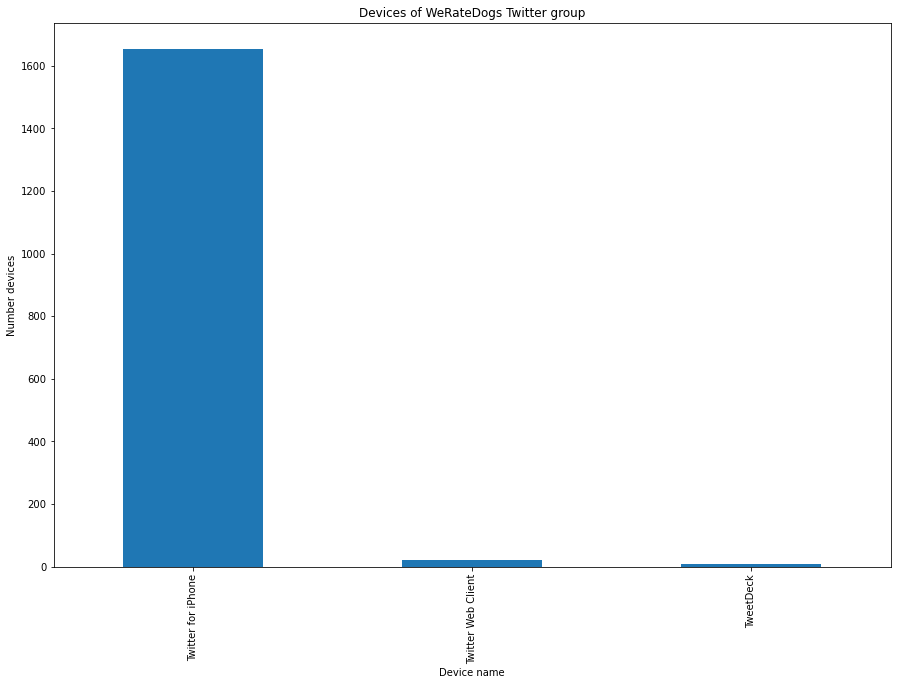

```python
plt.figure(figsize = (15,10))
plt.title('Devices of WeRateDogs Twitter group')
plt.ylabel('Number devices')
plt.xlabel('Device name')
df.device.value_counts().plot.bar()
```

### What are the top 10 most favorite tweets?

```python
favorites = df.iloc[df.favorite_count.sort_values(ascending = False)[:10].index].reset_index()
```

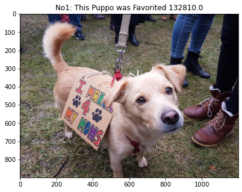

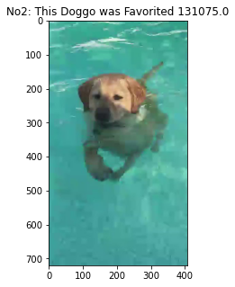

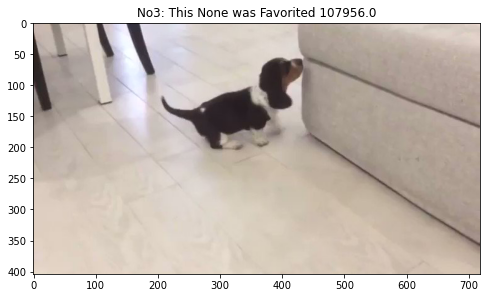

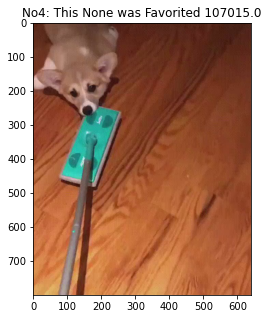

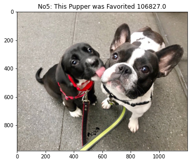

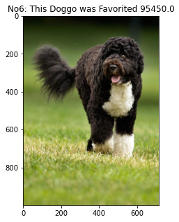

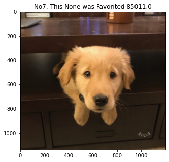

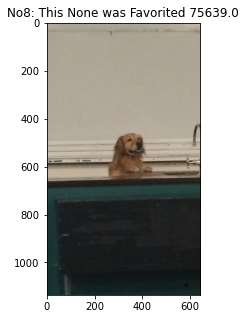

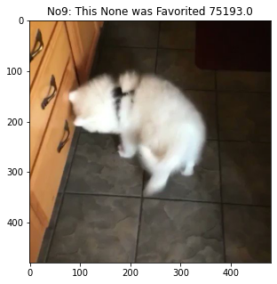

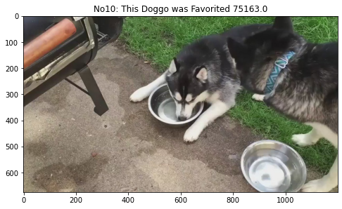

```python
i = 0
for url, dog, count in zip(favorites.jpg_url.values, favorites.dogtionary.values, favorites.favorite_count.values):
    i += 1
    img = plt.imread(url, format = 'jpg')
    plt.figure(figsize = (8,5))
    plt.title(f"No{i}: This {dog} was Favorited {count}")
    plt.imshow(img)
```

### What are the top 10 most retweeted tweets?

```python
retweets = df.iloc[df.retweet_count.sort_values(ascending = False)[:10].index]
```

[figure not shown]

[figure not shown]

[figure not shown]

[figure not shown]

[figure not shown]

[figure not shown]

[figure not shown]

[figure not shown]

[figure not shown]

[figure not shown]

```python
for url, dog, count in zip(retweets.jpg_url.values, retweets.dogtionary.values, retweets.favorite_count.values):
    i += 1
    img = plt.imread(url, format = 'jpg')
    plt.figure(figsize = (8,5))
    plt.title(f"No{i}: This {dog} was Retweeted {count}")
    plt.imshow(img)
```

### What day of the week and time of the day to people tweet the most?

[output not shown]

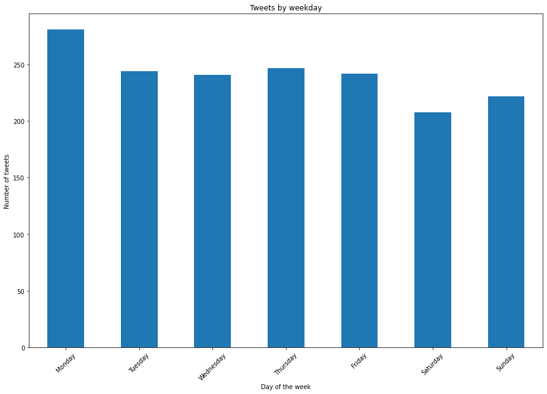

```python
from datetime import datetime
plt.figure(figsize = (15,10))
plt.title('Tweets by weekday')
plt.xlabel('Day of the week')
plt.ylabel('Number of tweets')
ax = df.timestamp.apply(lambda str_: datetime.strptime(str_, '%Y-%m-%d %H:%M:%S').weekday()).value_counts().sort_index().plot.bar()
ax.set_xticks(range(7))
ax.set_xticklabels(['Monday', 'Tuesday', 'Wednesday', 'Thursday', 'Friday', 'Saturday', 'Sunday'], rotation = 45)
```

Surprisingly peak tweet day is monday and little less on weekends compared to the average on during the week

[figure not shown]

```python
plt.figure(figsize = (15,10))
plt.title('Tweets by time of the day')
plt.xlabel('Day of the week')
plt.ylabel('Number of tweets')
df.timestamp.apply(lambda str_: datetime.strptime(str_, '%Y-%m-%d %H:%M:%S').hour).value_counts().sort_index().plot.bar()
```

The peak tweet time is at 0 and 1 in the morning... Which is GMT and for the US that might be around 4 and 5 pm.

### What are the top 10 dog names (despite noname)?

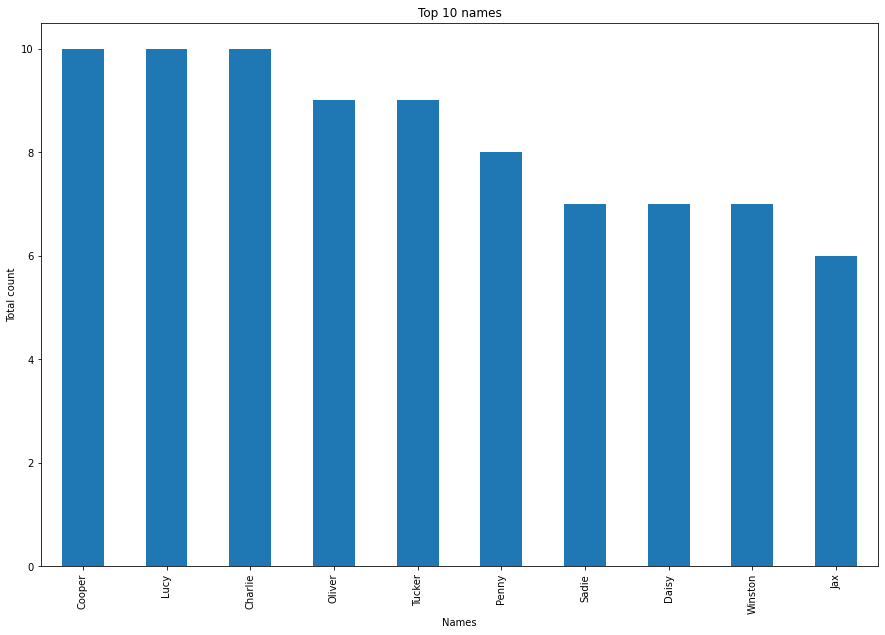

```python
plt.figure(figsize = (15,10))
plt.title('Top 10 names')
plt.xlabel('Names')
plt.ylabel('Total count')
df.name.value_counts()[1:11].plot.bar()
```